# Predicting the age of abalone

Abirham

2024-12-08

## 0.1 Methods

```r
#Run these commands to install all the required packages for this report
install.packages("readr")
install.packages("dplyr")
install.packages("car")
install.packages("lmtest")
install.packages("ggplot2")
install.packages("GGally")
install.packages("gridExtra")
install.packages("MASS")
install.packages("leaps")
install.packages("glmnet")
install.packages("caret")
install.packages("gbm")
```

```r
#loading all necessary packages
library(readr)
library(dplyr)
library(car)
library(lmtest)
library(ggplot2)
library(GGally)
library(gridExtra)
library(MASS)
library(leaps)
library(glmnet)
library(caret)
library(gbm)
```

```r
# Corrected file path with forward slashes
abalone=read.csv("D:/Githubfordatamining/FA24-DATS6101-11/HW/Abalone_data.csv")
head(abalone)
```

```
##   Sex Length Diameter Height Whole.weight Shucked.weight Viscera.weight
## 1   M  0.455    0.365  0.095       0.5140         0.2245         0.1010
## 2   M  0.350    0.265  0.090       0.2255         0.0995         0.0485
## 3   F  0.530    0.420  0.135       0.6770         0.2565         0.1415
## 4   M  0.440    0.365  0.125       0.5160         0.2155         0.1140
## 5   I  0.330    0.255  0.080       0.2050         0.0895         0.0395
## 6   I  0.425    0.300  0.095       0.3515         0.1410         0.0775
##   Shell.weight Rings
## 1        0.150    15
## 2        0.070     7
## 3        0.210     9
## 4        0.155    10
## 5        0.055     7
## 6        0.120     8
```

```r
abalone$Sex <- as.factor(abalone$Sex)
str(abalone, give.attr = FALSE)
```

```
## 'data.frame':    4177 obs. of  9 variables:
##  $ Sex           : Factor w/ 3 levels "F","I","M": 3 3 1 3 2 2 1 1 3 1 ...
##  $ Length        : num  0.455 0.35 0.53 0.44 0.33 0.425 0.53 0.545 0.475 0.55 ...
##  $ Diameter      : num  0.365 0.265 0.42 0.365 0.255 0.3 0.415 0.425 0.37 0.44 ...
##  $ Height        : num  0.095 0.09 0.135 0.125 0.08 0.095 0.15 0.125 0.125 0.15 ...
##  $ Whole.weight  : num  0.514 0.226 0.677 0.516 0.205 ...
##  $ Shucked.weight: num  0.2245 0.0995 0.2565 0.2155 0.0895 ...
##  $ Viscera.weight: num  0.101 0.0485 0.1415 0.114 0.0395 ...
##  $ Shell.weight  : num  0.15 0.07 0.21 0.155 0.055 0.12 0.33 0.26 0.165 0.32 ...
##  $ Rings         : int  15 7 9 10 7 8 20 16 9 19 ...
```

```r
library(knitr)
kable(abalone[1:10,], digits = 4,format = 'markdown')
```

| Sex | Length | Diameter | Height | Whole.weight | Shucked.weight | Viscera.weight | Shell.weight | Rings |
| --- | --- | --- | --- | --- | --- | --- | --- | --- |
| M | 0.455 | 0.365 | 0.095 | 0.5140 | 0.2245 | 0.1010 | 0.150 | 15 |
| M | 0.350 | 0.265 | 0.090 | 0.2255 | 0.0995 | 0.0485 | 0.070 | 7 |
| F | 0.530 | 0.420 | 0.135 | 0.6770 | 0.2565 | 0.1415 | 0.210 | 9 |
| M | 0.440 | 0.365 | 0.125 | 0.5160 | 0.2155 | 0.1140 | 0.155 | 10 |
| I | 0.330 | 0.255 | 0.080 | 0.2050 | 0.0895 | 0.0395 | 0.055 | 7 |
| I | 0.425 | 0.300 | 0.095 | 0.3515 | 0.1410 | 0.0775 | 0.120 | 8 |
| F | 0.530 | 0.415 | 0.150 | 0.7775 | 0.2370 | 0.1415 | 0.330 | 20 |
| F | 0.545 | 0.425 | 0.125 | 0.7680 | 0.2940 | 0.1495 | 0.260 | 16 |
| M | 0.475 | 0.370 | 0.125 | 0.5095 | 0.2165 | 0.1125 | 0.165 | 9 |
| F | 0.550 | 0.440 | 0.150 | 0.8945 | 0.3145 | 0.1510 | 0.320 | 19 |

```r
library(skimr)
skim(abalone)
```

Data summary

| Name | abalone |
| --- | --- |
| Number of rows | 4177 |
| Number of columns | 9 |
| _______________________ |  |
| Column type frequency: |  |
| factor | 1 |
| numeric | 8 |
| ________________________ |  |
| Group variables | None |

**Variable type: factor**

| skim_variable | n_missing | complete_rate | ordered | n_unique | top_counts |
| --- | --- | --- | --- | --- | --- |
| Sex | 0 | 1 | FALSE | 3 | M: 1528, I: 1342, F: 1307 |

**Variable type: numeric**

| skim_variable | n_missing | complete_rate | mean | sd | p0 | p25 | p50 | p75 | p100 | hist |
| --- | --- | --- | --- | --- | --- | --- | --- | --- | --- | --- |
| Length | 0 | 1 | 0.52 | 0.12 | 0.07 | 0.45 | 0.54 | 0.62 | 0.81 | ▁▂▅▇▂ |
| Diameter | 0 | 1 | 0.41 | 0.10 | 0.06 | 0.35 | 0.42 | 0.48 | 0.65 | ▁▂▆▇▁ |
| Height | 0 | 1 | 0.14 | 0.04 | 0.00 | 0.12 | 0.14 | 0.16 | 1.13 | ▇▁▁▁▁ |
| Whole.weight | 0 | 1 | 0.83 | 0.49 | 0.00 | 0.44 | 0.80 | 1.15 | 2.83 | ▇▇▅▁▁ |
| Shucked.weight | 0 | 1 | 0.36 | 0.22 | 0.00 | 0.19 | 0.34 | 0.50 | 1.49 | ▇▇▂▁▁ |
| Viscera.weight | 0 | 1 | 0.18 | 0.11 | 0.00 | 0.09 | 0.17 | 0.25 | 0.76 | ▇▇▂▁▁ |
| Shell.weight | 0 | 1 | 0.24 | 0.14 | 0.00 | 0.13 | 0.23 | 0.33 | 1.00 | ▇▇▂▁▁ |
| Rings | 0 | 1 | 9.93 | 3.22 | 1.00 | 8.00 | 9.00 | 11.00 | 29.00 | ▁▇▂▁▁ |

```r
categoric_features <- colnames(abalone)[sapply(abalone, function(col) is.factor(col) || is.character(col))]

categoric_features
```

```
## [1] "Sex"
```

```r
numeric_features <- abalone %>%
  select_if(is.numeric) %>%
  colnames()
numeric_features
```

```
## [1] "Length"         "Diameter"       "Height"         "Whole.weight"
## [5] "Shucked.weight" "Viscera.weight" "Shell.weight"   "Rings"
```

The dataset contains information on 4177 abalones, each described by 9 variables. Below is an overview of the dataset’s structure:

Sex (Categorical): Indicates the gender of the abalone, represented as “M” (male), “F” (female), or “I” (infant). Length (Numeric): The longest measurement of the abalone in millimeters. Diameter (Numeric): The perpendicular width of the abalone. Height (Numeric): The height of the abalone with the shell on. Whole weight (Numeric): The weight of the whole abalone in grams. Shucked weight (Numeric): The weight of the meat extracted from the abalone in grams. Viscera weight (Numeric): The weight of the gut content in grams. Shell weight (Numeric): The weight of the dried shell in grams. Rings (Numeric): The number of growth rings observed in the shell, which serves as the dependent variable.

Looking at the data set above summary, we can see that data is quite evenly distributed between the three factor levels of male, female and infant.

Also we see that there are four different measure of weight i.e. Whole_weight, Shucked_weight, Viscera_weight and Shell.weight. Whole_weight is linear function of other weight predictors with Unknown mass of water/blood lost from shucking process.

Response variable: The dependent variable, Rings, is included in the dataset and represents the number of rings observed after cutting and examining an abalone. While it does not directly indicate the age of an abalone, it serves as a reliable proxy. The age of an abalone can be calculated as Age=Rings + 1.5. Given the consistency of this relationship, Rings will be treated as the dependent variable in the analysis. The number of rings recorded in the dataset ranges from 1 to 29, with the majority of abalones having between 5 and 15 rings. The distribution is slightly positively skewed, but this does not present any significant challenges for the subsequent analysis.

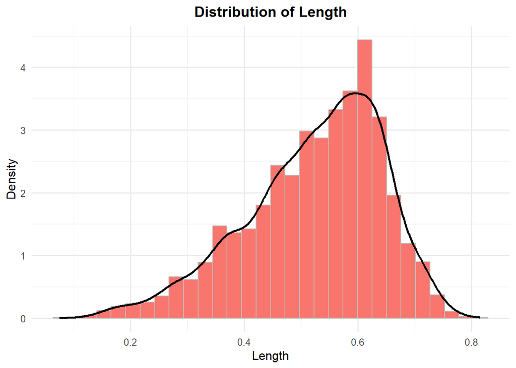

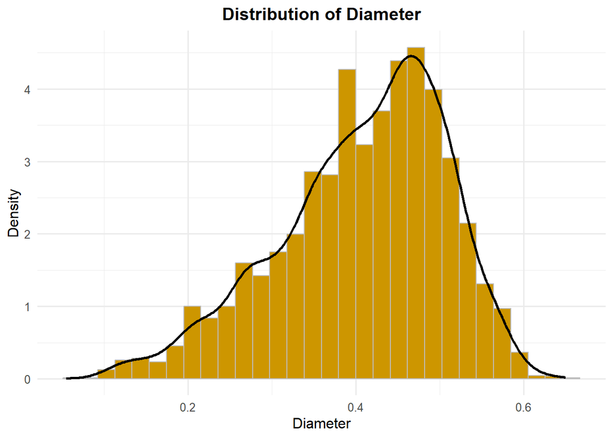

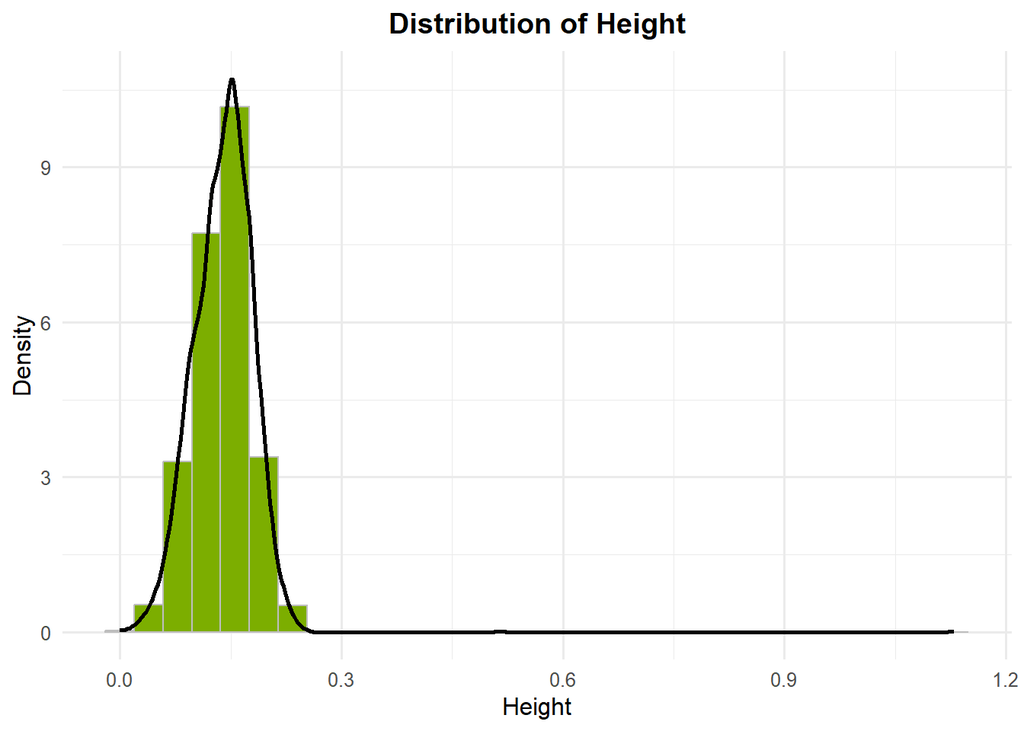

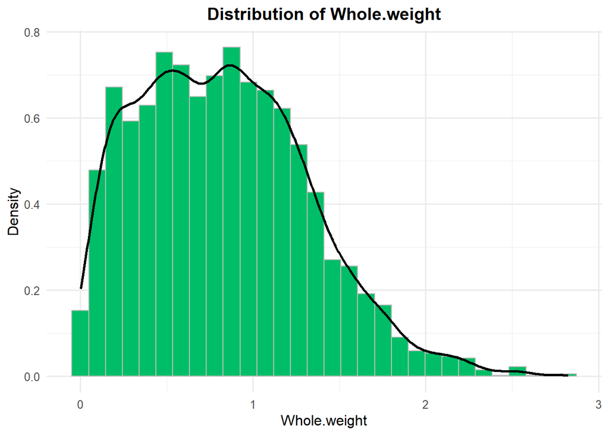

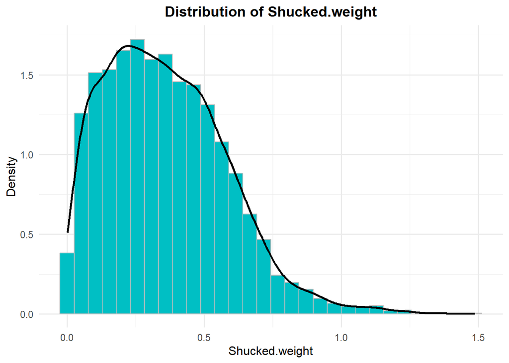

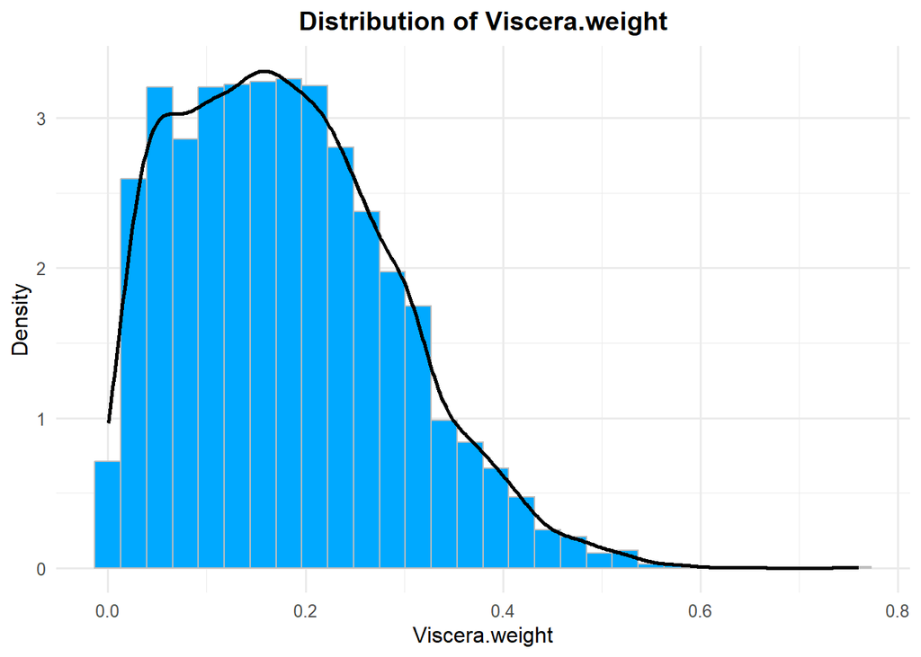

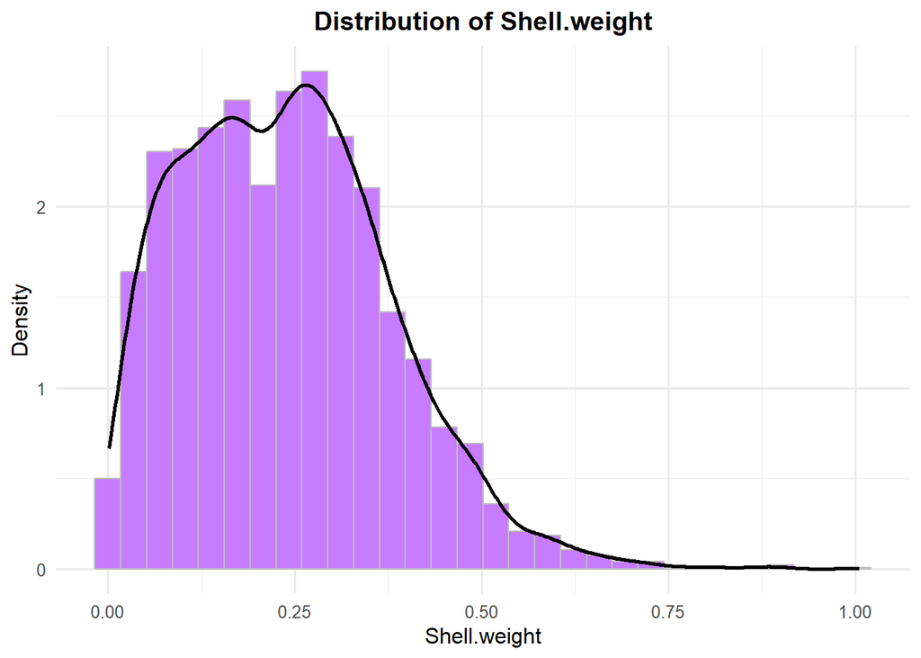

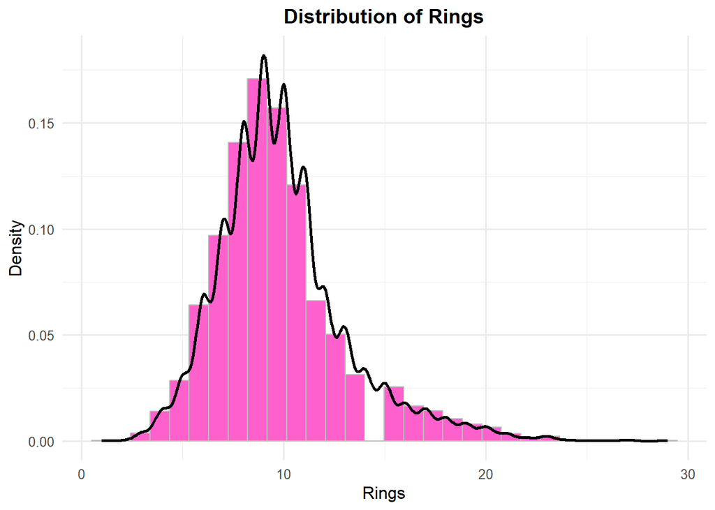

```r
library(ggplot2)
library(gridExtra)
library(grid)

numeric_features <- colnames(abalone)[sapply(abalone, is.numeric)]
# Create a list to store individual ggplot objects
plots <- list()

# Generate histograms for each numeric feature
for (i in seq_along(numeric_features)) {
  num_feat <- numeric_features[i]
  p <- ggplot(abalone, aes_string(x = num_feat)) +
    geom_histogram(aes(y = ..density..), color = "gray",
                   fill = scales::hue_pal()(length(numeric_features))[i], bins = 30) +
    geom_density(color = "black", size = 1) +
    labs(title = paste("Distribution of", num_feat),
         x = num_feat,
         y = "Density") +
    theme_minimal(base_size = 12) +
    theme(plot.title = element_text(hjust = 0.5, face = "bold"))

  # Print each plot to check
  print(p)

  # Store the plot in the list
  plots[[i]] <- p
}
```

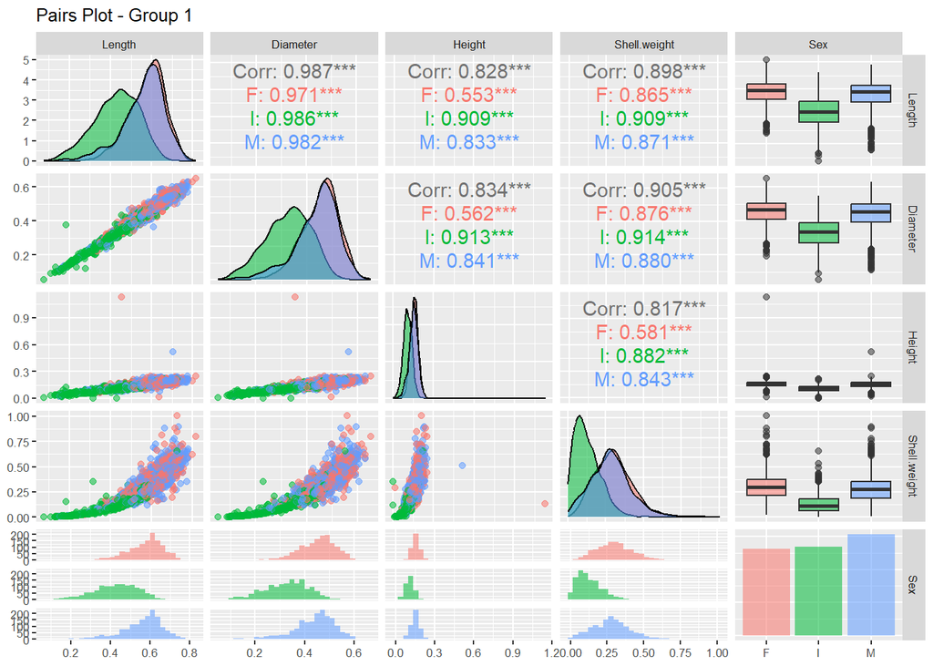

```r
group_1 <- c("Length", "Diameter", "Height","Shell.weight")
group_2 <- c("Whole.weight", "Shucked.weight","Viscera.weight" ,"Rings")

# First pairs plot
plot1 <- ggpairs(abalone[, c(group_1, "Sex")],
                 aes(colour = Sex, alpha = 0.8),
                 title = "Pairs Plot - Group 1") +
  theme_grey(base_size = 8)

# Second pairs plot
plot2 <- ggpairs(abalone[, c(group_2, "Sex")],
                 aes(colour = Sex, alpha = 0.8),
                 title = "Pairs Plot - Group 2") +
  theme_grey(base_size = 8)

# Display both plots
print(plot1)
```

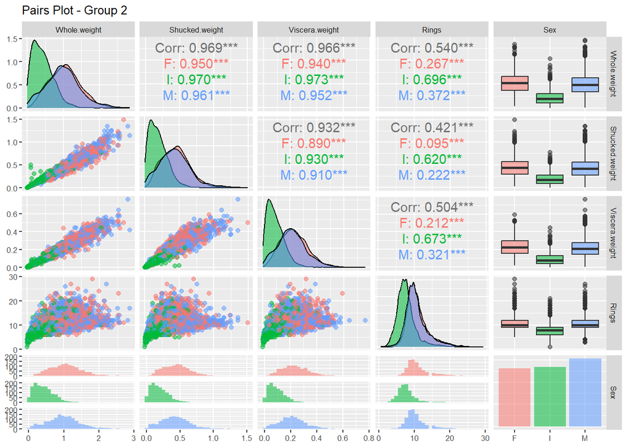

```r
print(plot2)
```

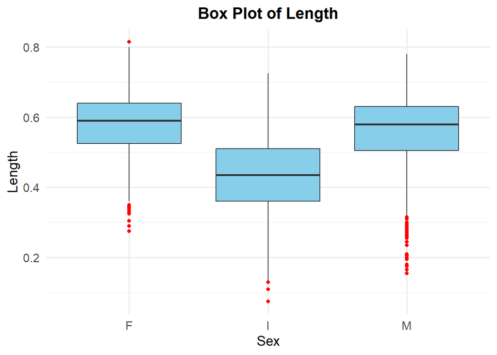

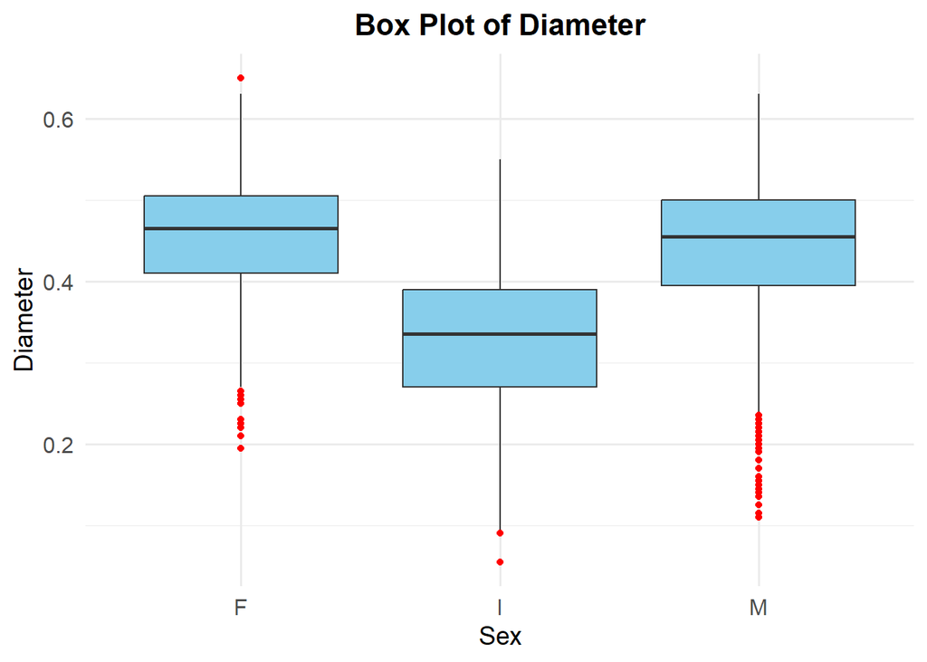

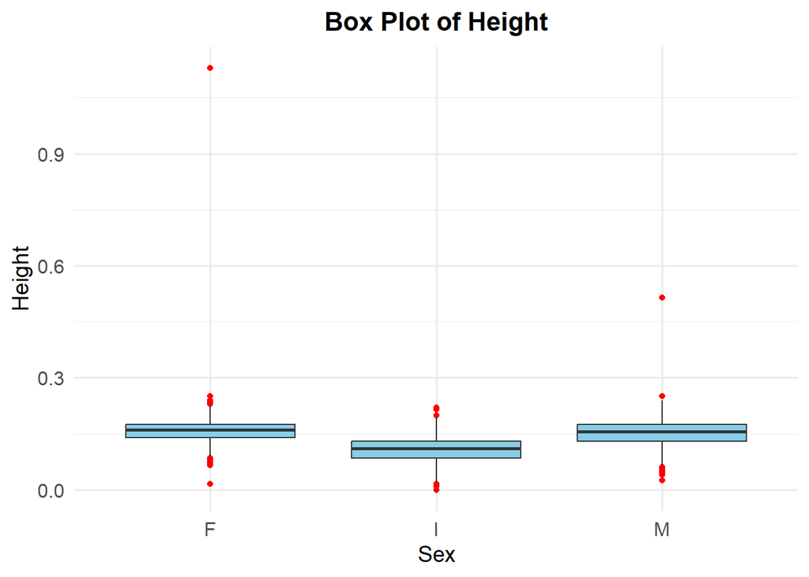

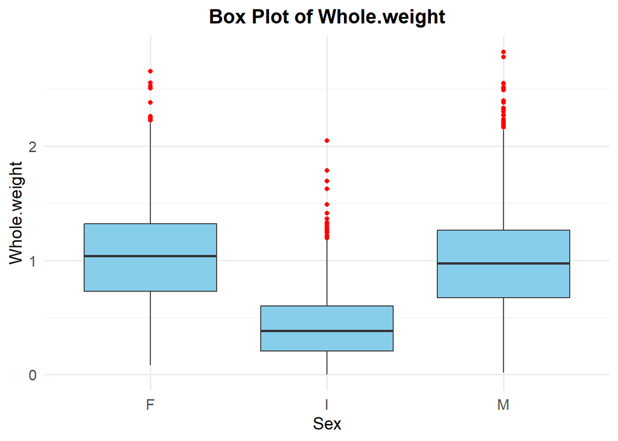

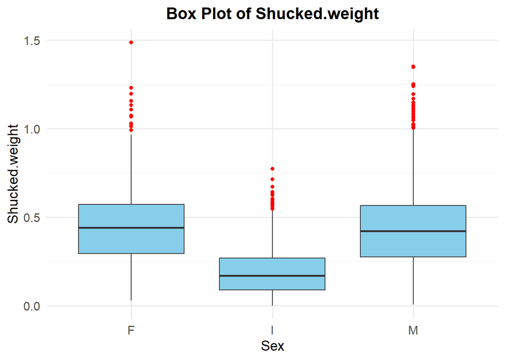

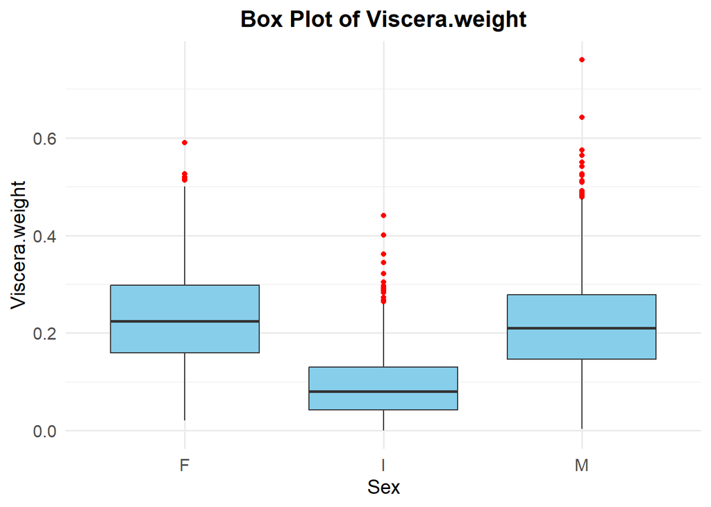

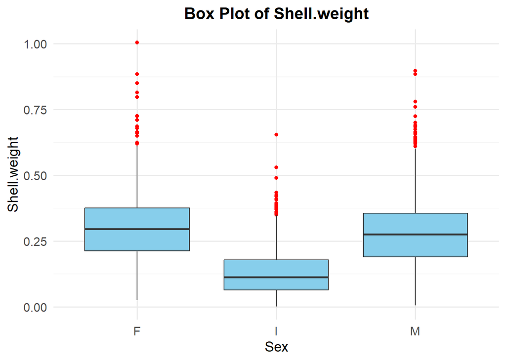

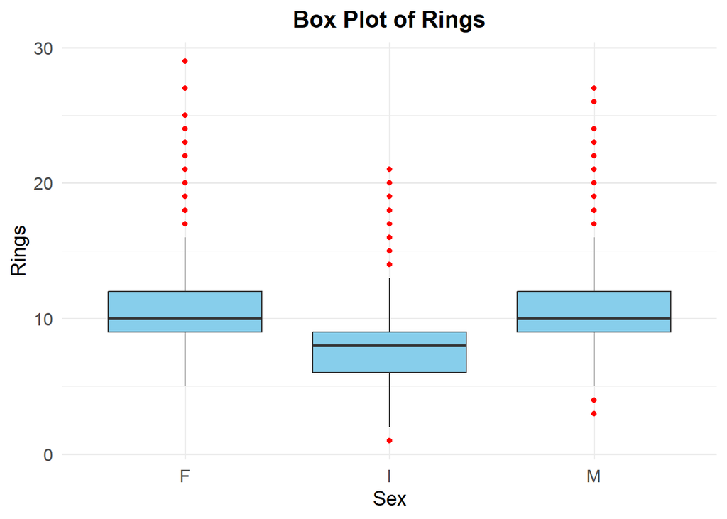

```r
library(ggplot2)
for (num_feat in numeric_features) {
  p <- ggplot(data = abalone, aes_string(x = "Sex", y = num_feat)) +
    geom_boxplot(fill = "skyblue", outlier.color = "red", outlier.size = 1.5) + # Custom fill color
    labs(
      title = paste("Box Plot of", num_feat),
      x = "Sex",
      y = num_feat
    ) +
    theme_minimal(base_size = 14) +
    theme(
      plot.title = element_text(hjust = 0.5, face = "bold", size = 16),
      axis.text = element_text(size = 12),
      axis.title = element_text(size = 14)
    )

  print(p)
}
```


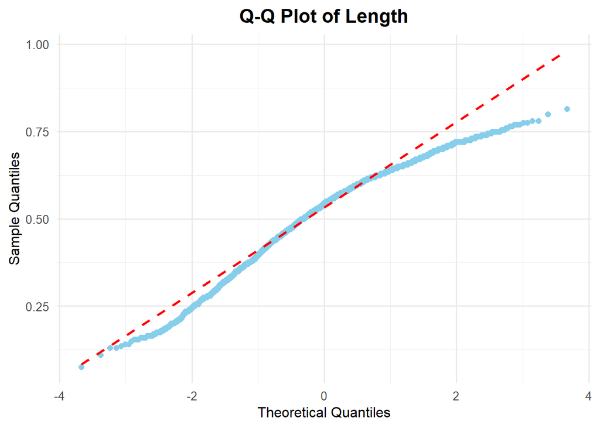

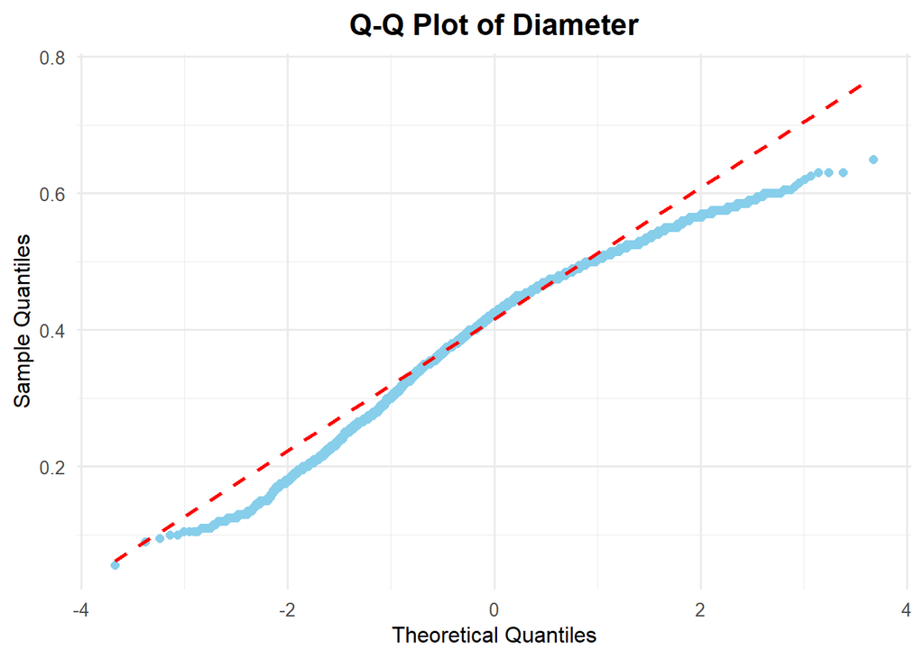

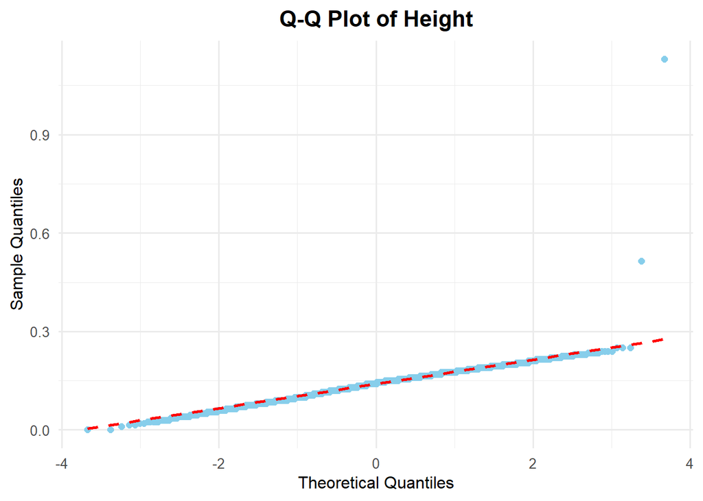

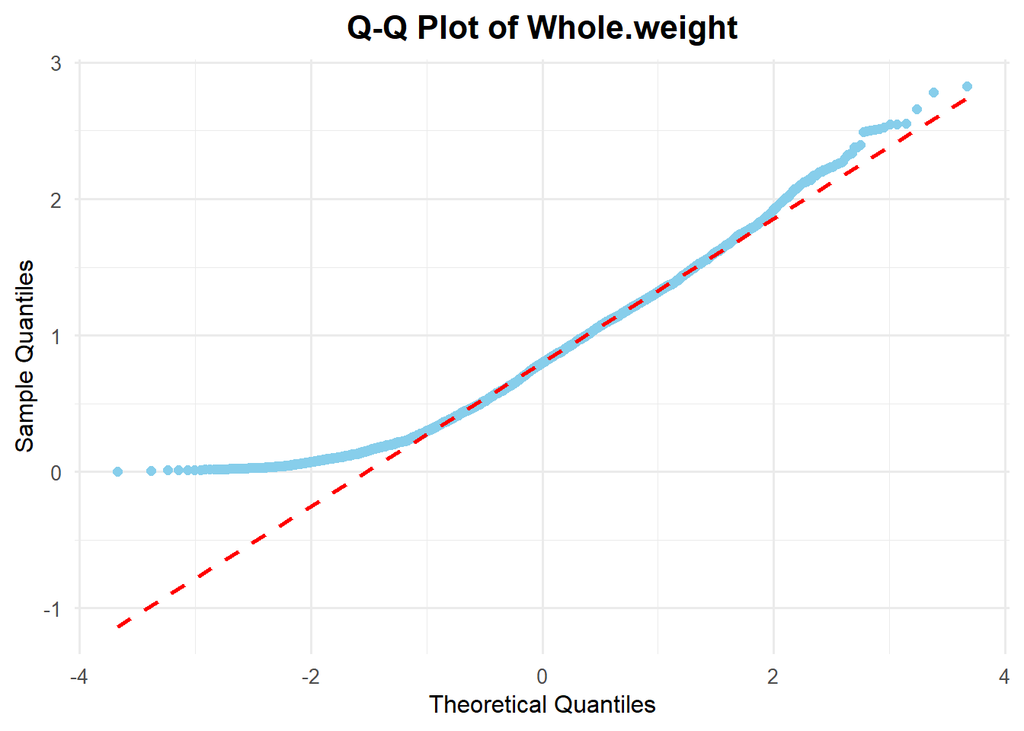

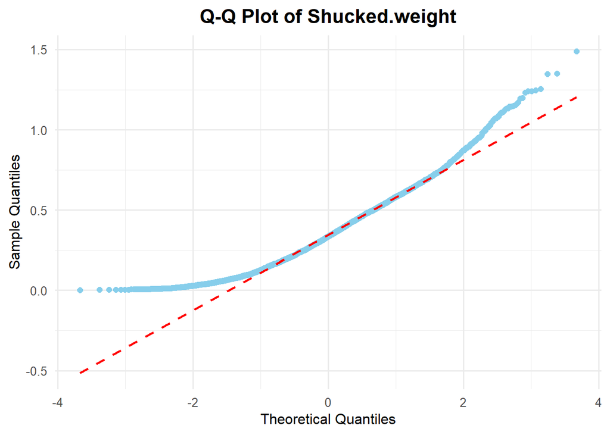

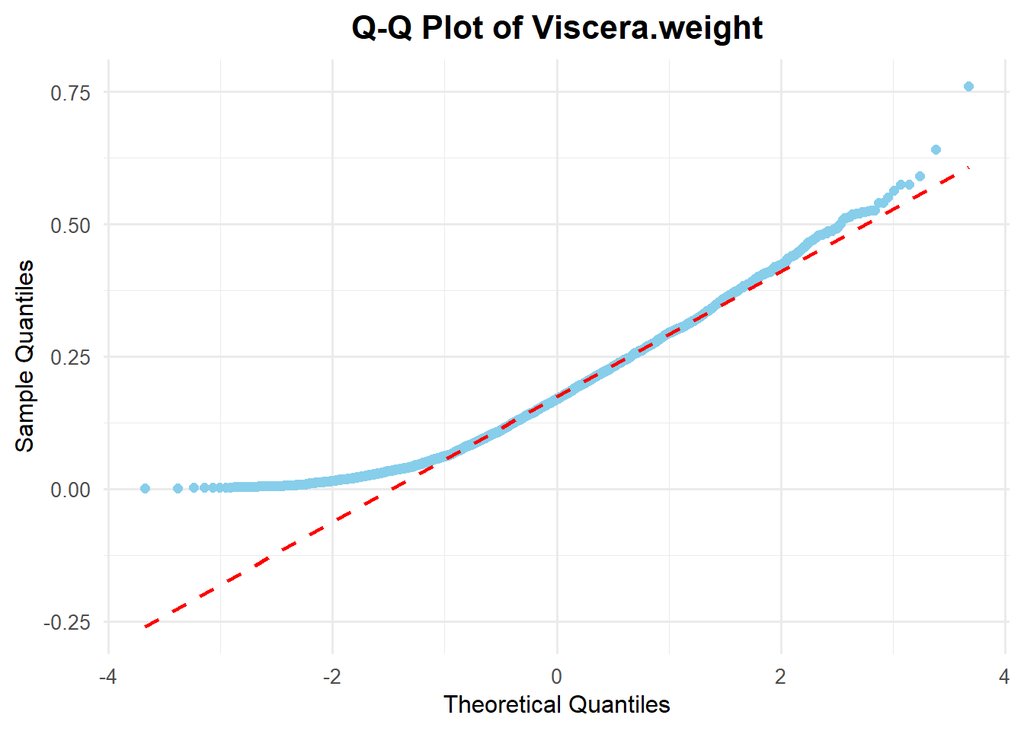

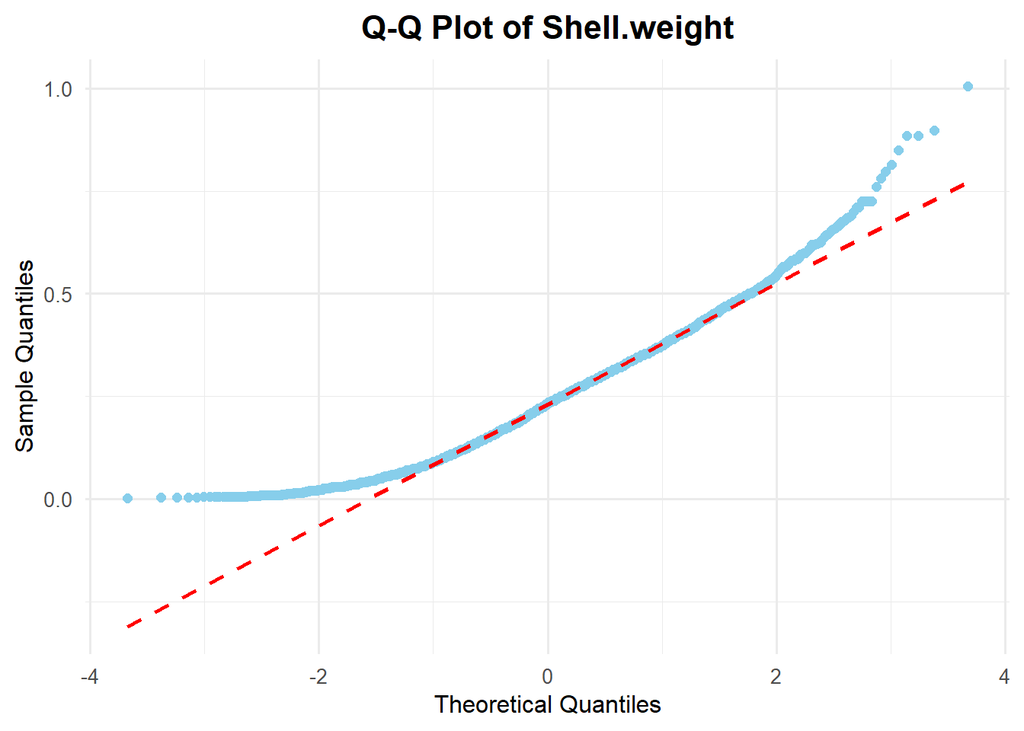

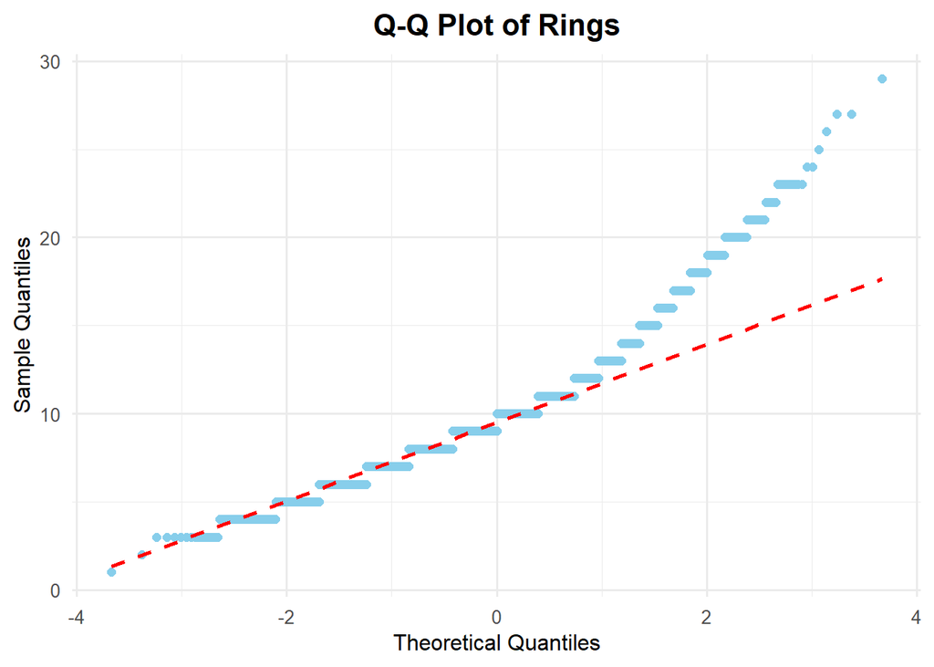

```r
library(ggplot2)
library(patchwork)
library(gridExtra)
library(ggplot2)

numeric_features <- colnames(abalone)[sapply(abalone, is.numeric)]

# Loop through each numeric feature and create Q-Q plots separately
for (num_feat in numeric_features) {
  # Generate the Q-Q plot
  p <- ggplot(data = abalone, aes(sample = .data[[num_feat]])) +
    stat_qq(color = "skyblue", size = 2) +  # Q-Q plot points
    stat_qq_line(color = "red", linetype = "dashed", size = 1) +  # Reference line
    labs(
      title = paste("Q-Q Plot of", num_feat),
      x = "Theoretical Quantiles",
      y = "Sample Quantiles"
    ) +
    theme_minimal(base_size = 14) +
    theme(
      plot.title = element_text(hjust = 0.5, face = "bold", size = 16),
      axis.text = element_text(size = 10),
      axis.title = element_text(size = 12)
    )

  print(p)
}
```

The Q-Q plot for Rings shows a step-like pattern, reflecting the discrete nature of the variable. While the central portion aligns with the normal distribution line, the tails deviate, particularly on the higher end.

These results suggest the need for potential transformations when modeling variables like weights and Rings to improve normality assumptions.

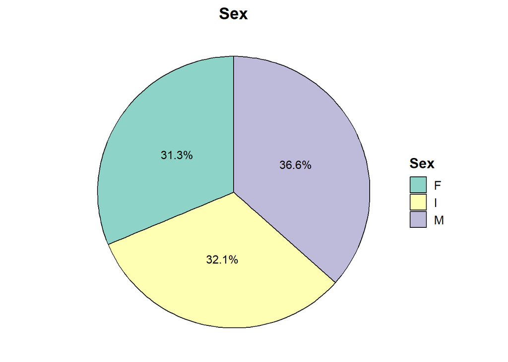

```r
library(ggplot2)
library(dplyr)

categoric_feature <- colnames(abalone)[sapply(abalone, is.factor)][1]


category_counts <- abalone %>%
  count(.data[[categoric_feature]]) %>%
  mutate(Percentage = n / sum(n) * 100)

ggplot(category_counts, aes(x = "", y = Percentage, fill = .data[[categoric_feature]])) +
  geom_bar(stat = "identity", width = 1, color = "black") +
  coord_polar(theta = "y", start = 0) +
  scale_fill_brewer(palette = "Set3") +
  labs(
    title = categoric_feature,
    fill = categoric_feature
  ) +
  theme_void(base_size = 14) +
  theme(
    plot.title = element_text(hjust = 0.5, face = "bold", size = 16),
    legend.title = element_text(size = 14, face = "bold"),
    legend.text = element_text(size = 12)
  ) +
  geom_text(
    aes(label = sprintf("%.1f%%", Percentage)),
    position = position_stack(vjust = 0.5),
    size = 4,
    color = "black"
  )
```

As it is indicated in the pie chart the distribution is fairly balanced across the three categories, with males slightly outnumbering the other two groups. from this we can say that sex-based analysis can be conducted without any major skew between groups.

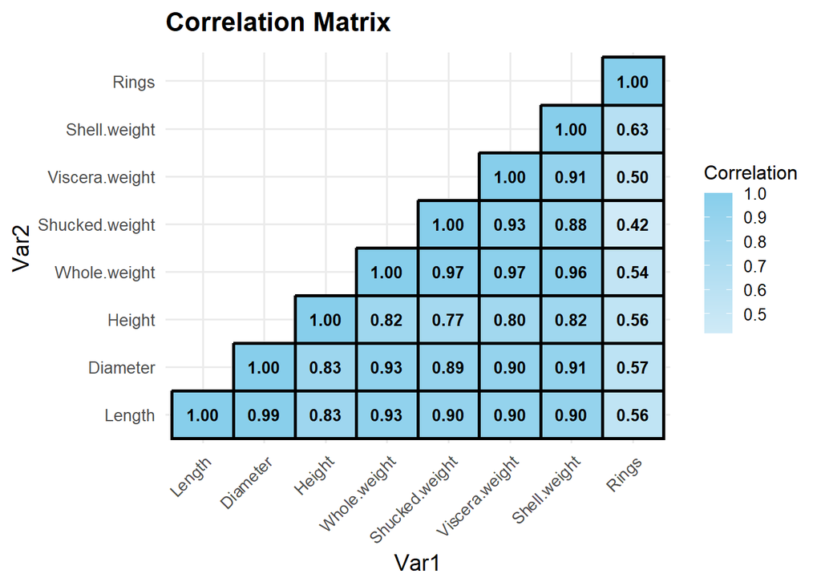

```r
library(reshape2)

numeric_features <- colnames(abalone)[sapply(abalone, is.numeric)]
corr_matrix <- cor(abalone[, numeric_features], use = "complete.obs", method = "pearson")
mask <- upper.tri(corr_matrix)


corr_melt <- melt(corr_matrix)
corr_melt <- corr_melt[!mask, ]

ggplot(corr_melt, aes(Var1, Var2, fill = value)) +
  geom_tile(color = "black", linewidth = 1) +
  scale_fill_gradient2(low = "red", high = "skyblue", mid = "white", midpoint = 0) +
  geom_text(aes(label = sprintf("%.2f", value)), size = 3.5, fontface = "bold", color = "black") +
  labs(title = "Correlation Matrix", fill = "Correlation") +
  theme_minimal(base_size = 14) +
  theme(
    plot.title = element_text(hjust = 0, face = "bold", size = 16, margin = margin(b = 10)),
    axis.text.x = element_text(angle = 45, hjust = 1, size = 10),
    axis.text.y = element_text(size = 10),
    legend.title = element_text(size = 12),
    legend.text = element_text(size = 10)
  )
```

The correlation matrix shows that there is a strong interdependence among physical and weight features, while Rings is moderately correlated with size variables, particularly Shell Weight. These insights suggest that multicollinearity might need to be addressed when building predictive models, and Shell Weight could be a strong predictor of age